# Reviewing Reviews in Yelp

### By: Faris Aziz, Michael Pocress, Ru Feng

### 12/11/2020

# Introduction

#### Background/Context

Yelp is a public US corporation founded in 2004. The company’s main service offering is the Yelp.com website and Yelp mobile app, which publishes reviews about businesses. The company also provides an online reservation system called Yelp reservations. Yelp works by allowing its online users to rank the quality of a business from a one to five-star rating system. The main function of Yelp is to provide users information about the quality of offerings from businesses in a particular area.

The data set that our team chose to work with is a subset of Yelp’s user data, reviews, and businesses. Our data set is diverse in its scope – information about reviews are collected from eleven metropolitan areas across four countries. In summary, our data collects information about 5.2 million user reviews and 174,000 businesses.

Our group feels that this project is important for a number of reasons. First, due to the pandemic consumers are increasingly relying on online reviews to assess the quality of business offerings (i.e. there is less in-person trials). People are relying more on the infomration they collect from the internet. Second, ratings can affect the number of visitors to a particular business and thus the revenue it earns. Through our project we provide a deeper examination into Yelp's five start rating to better understand how the choice of words in reviews and a business's location can impact the rating it receives on the platform.

#### Key Terms

- Stars: The number of stars a reviewer rated a restaraunt in a review.
- Rural: A low population area/ town.
- Urban: A high population area/ city.

#### Research Questions

1) How do ratings of restaurants influence positive/ negative word choice?

2) What's the distribution of ratings based on urban vs rural locations in the U.S.?

#### Key Findings

- We found that for the first research question, people tend to use positive words more in 3, 4, and 5 star reviews than in 1 and 2 star reviews. We also found that people tend to use negative words regardless of the review type.
- For the second research question, we found that there was no significant difference between urban and rural locations in terms of review stars.

#### Data Sources

To conduct this research, we focused on the following data sources:

- Yelp Dataset: https://www.kaggle.com/yelp-dataset/yelp-dataset/data
- Population Data by Location in the US: https://www.census.gov/data/datasets/time-series/demo/popest/2010s-total-cities-and-towns.html#tables (The dataset is called the 'Annual Estimates of the Resident Population for Incorporated Places of 50,000 or More, Ranked by July 1, 2019 Population: April 1, 2010 to July 1, 2019')
  - This was used as a supplementary dataset to look at population counts in major cities for our second analysis.

# Data Description

### Motivation

Our team was motivated to use this data set mainly because members of the team are all users of the Yelp platform. Thus, we are very interested in analyzing how accurate business reviews are on the site. For example, team members discussed times where (s)he has visited a business ranked very highly (e.g. 5 stars) or very poorly (e.g. 1 star on the help platform) and have found the rating was not accurate. In this section, we also would like to answer the follwo questions:

- For what purpose was the data set created?
  - The data set was originally put together for the Yelp Dataset Challenge. This challenge is an assignment organized by Yelp to that encourages students to conduct research on Yelp’s data and share their discoveries.
- Who created the data set (e.g., which team, research group) and on behalf of which entity (e.g., company, institution, organization)?
  - This data set was found on an open-access site (Kaggle), the data was published on Kaggle by Yelp Inc. and a collaborator Chris Crawford. The data set was last updated 6 months ago.
- Who funded the creation of the data set?
  - Not specified

### Key Composition Points

Data composition is analysis of the different elements part of a data set. In this section of the report, our group wanted to answer the following points about our data set:

### Data Collection Process

The data collection process is important to identify potential issues in our data set. Outlining steps in the data collection process is important to explain to others who wish to reconstruct or verify the data set if they do not have access to it. In this section we wanted to answer the following questions:

- Who was involved in the data collection process (e.g., students, crowdworkers, contractors) and how were they compensated (e.g., how much were crowdworkers paid)? Who was involved in the data collection process (e.g., students, crowdworkers, contractors) and how were they compensated (e.g., how much were crowdworkers paid)?
  - There were two main parties involved in the Yelp data set our group used for the project: Yelp Inc. and Chris Crawford, a senior data engineer based out of Seattle, Washington. No information was given as to the remuneration involved in collecting this data set.
- If the dataset is a sample from a larger set, what was the sampling strategy (e.g., deterministic, probabilistic with specific sampling probabilities)?
  - As mentioned, our data set is not from a larger data set and a sampling strategy in the data collection process was not used.
- Over what timeframe was the data collected?
  - Reviews information was collected from 2004-2019 (15 years).
- Did you collect the data from the individuals in question directly, or obtain it via third parties or other sources (e.g., websites)?
  - Data was not collected from individuals directly but rather a third-party source (Kaggle).
- Were the individuals in question notified about the data collection?
  - Data from over two million users were collected and compiled in this data set. No users were notified that their ratings scores and comments about business would be compiled in this data set. This is mainly because registered Yelp users consent to having their data analyzed and processed by Yelp. In order to access the site. This helps Yelp improves its services.
- Has an analysis of the potential impact of the dataset and its use on data subjects (e.g., a data protection impact analysis) been conducted?
  - Analysis of the impact of the data set has on the data subjects has not been analyzed yet. While we are planning to analyze this more through the next steps of our project, there has been studies in the past that analyze the impact of Yelp ratings. For example, the relationship between ratings and business bookings – which is important to its sustainability.

### Objectives and Stakeholders

Some preliminary objectives our group has are the following:

- Better understand what does the different star ratings mean?
- Understand the accuracy and variability of ratings for businesses on Yelp’s platform
- Hypothesize what factors (e.g. location, type of establishment, parking, etc.) that makes Yelp users lean towards rating a business 2, 3, vs 4 stars

It is very important to analyze who the stakeholders may be in this data science project. A stakeholder may be defined as any party that is impacted or involved in our study or analysis. After several team meetings, our group has identified three key stakeholders involved in this data science project:

- Yelp Users. Yelp has about over 175 million users visit the site every month across the company’s app, mobile, and desktop versions. These people visit Yelp to receive reliable information about business services and product offerings. It is important that the reviews provided on the Yelp.com website reflect the quality of the business.
- Yelp Business Organizations listed on the Yelp website. As of December 2018, there were 5 million businesses listed on Yelp. Yelp aides businesses on its site via two main ways:
  - It can allow businesses to get discovered; especially those located in remote areas. This can increase the number of customers a business attracts.
  - Businesses can advertise on Yelp; this is one of the main ways that Yelp earns revenue from its platform. For example, a local pizza joint can advertise its menu or daily specials on Yelp.
- Yelp. The company wants to ensure that the ratings and reviews of the businesses on its site are fair and accurate. Doing so allows Yelp to preserve its business reputation and can attract more visitors to its platform.

This can also aid policy makers too. Yelp in the past has had class action lawsuits filed against the company with allegations that Yelp forces businesses into buying advertising spots on its platform. Policy makers can use the information collected from our project to assess whether higher rated businesses on Yelp are normally those that pay for advertising on the platform. There have also been allegations that Yelp salespeople can suppress the negative reviews a business receives if they purchase advertising.

### Description of Variables

| Variable | Description |
| --- | --- |
| ‘business_id’ | Yelp assigns each business on its website an identification number. Businesses with multiple locations operating under the same business name are given different identification numbers |
| ‘name’ | the registered title of the business |
| ‘city’ | the city the business operates in |
| ‘state’ | the state the business is located in |
| ‘postal_code’ | postal code used for the business’s mailing address |
| ‘latitude’ | the north-south position of a point |
| ‘longitude’ | the east-west position of a point |
| ‘stars’ | the business’s average rating (in number of stars) across all the ratings given to it by users |
| ‘review_count’ | the number of reviews for a business on Yelp |
| ‘categories’ | the type or style of the business (e.g. grocery, sandwiches, specialty food, etc.) |
| ‘hours’ | hours of operation of the business |
| ‘user_id’ | the ID of the user giving the rating |
| ‘review_stars' | the number of stars a business received from a Yelp user |
| 'useful’ | one of the three types of quick responses a user can give a business on their page |
| 'funny' | one of the three types of quick responses a user can give a business on their page |
| ‘cool’ | one of the three types of quick responses a user can give a business on their page |
| ‘text’ | a string of the comment left by the user |
| ‘date’ | the data a rating is assigned |

### Data Set Limitations, Concerns, and Mitigation

No matter how reliable a data set is, there can be biases present in a data set that may be a cause of concern for the findings of the data set. Some examples of limitations in a data set can include missing values, false information, variations in the quality and the format of the data, outdated data, the presence of extreme values (e.g. outliers), variability in the type of data being used (e.g. decimals, characters, integers, character type), and more. In the context of our project, it is important to note that the data we collected mainly relies on Yelp reviews. However, our group has three main concerns about Yelp reviews. In the below table, we have identified each concern associated with our data set and how each concern can affect our results:

| Concern | Why It’s important |
| --- | --- |
| All reviews may not be completely human generated. Bots and hackers may choose to target the Yelp platform in an effort to promote fake news. | If this is the case, the results that we collect from our data set can lead to false information |

In order to mitigate these concerns, Yelp has established a messaging feature on its platform allowing business owners to privately or publicly message the reviewer on their profile to discuss the concerns. This can help prevent the spread of false information on Yelp’s platform. Additionally, Yelp has an automated review filter that aims to protect both businesses and customers. Yelp’s automated review filter algorithm analyzes each review that is written on a business’s Yelp page to assess which reviews will be displayed. This is an internal approach Yelp has taken to mitigate concerns outlined above.

# Preregistration Statements

## #1: How do words under positive/ negative contexts influence ratings of restaurants?

We would like to examine the relationship between the number of stars in reviews for restaurants versus the amount of positive and negative words.

#### Hypothesis & Experiment

Our hypothesis is that 5 star reviews will have positive feelings associated, such as “excellent”, “love”, etc. with it. We think that 1 star reviews will have negative feelings associated with it, such as “terrible”, “hate”, etc. We believe that the “in-between ratings,” 3 stars would have words that are associated with feelings of mediocrity, 2 stars would have words with more negative feelings but some positive, 4 stars would have words that are more associated with more positive but some negative feelings.

It is generally the accepted idea that 5 stars for a business would mean that the reviewer has a positive experience and 1 star review means the opposite. 3 stars would mean that the reviewer felt it was a fair experience, perhaps not the best or the worst. We want to dive into what is the general cut off for each of the ratings; we would like to examine the distribution of the positive and negative words in the reviews of the restaurants.

We aim to do this by comparing the positive words list between the different star ratings and the negative words list between the different ratings and using a t-test to find the differences between review stars and positivity/ negativity.

The experiment would be to take the top 10 words (by frequency) that are considered as “positive” and the top 10 words (by frequency) that are considered as “negative” from the reviews dataset. Then, we will conduct text analysis to examine how many of these words appear in each review pertaining to the different star categories and calculate the proportion of each rating. We will look at on average what each proportion is.

#### Rationale and Real World Significance

This analysis may seem like common sense and obvious to some, but if we look further into the idea, people have not tested the patterns that occur within reviews. These patterns can lead to interesting conclusions about how people tend to showcase their opinions in the form of reviews. By analyzing these patterns, we can get some interesting results and hypothesize the behavior of how people interact when conducting criticism of people. Therefore, this can lead to some interesting sociological/ psychological ideas in future experiments regarding people's opinions.

If lower proportion (for 2 to 5 stars, meaning less positive words than hypothesized):

- On average, reviewers are hyper critical to restaurant businesses and would be more likely to leave a review with more feelings of negativity despite a potentially otherwise positive experience if it were not for one incident. The dataset might be biased towards this as people tend to leave negative reviews more frequently than positive reviews.

If higher proportion (meaning more positive words than hypothesized):

- On average, it means that people tend to be more understanding to restaurant businesses, and can leave positive criticism as an idea of being nice.

The results can make businesses be more cautious of potentially where to best manage their budget on average. Perhaps a certain word/phrase (like ‘friendly’) that frequently appears that’s associated with a higher than expected proportion of positive to negative reviews. This means that restaurants should invest more into staff members and cut down on other aspects of their businesses if they can. This experiment can be broadened to the study of human behavior where we are trying to see to what extent is the statement about people remembering one negative experience over multiple positive experiences true.

## #2 What's the distribution of ratings based on urban vs rural locations?

We would like to see if the type of area the restaurants are located in has an effect on the distribution of ratings of the businesses.

#### Hypothesis & Experiment

We hypothesize that rural areas or less crowded locations will see on average a higher distribution of higher star (4 and 5 stars) reviews because we believe that people there tend to be more of a community and therefore, more understanding and less critical. They may have a higher tolerance for small mistakes that may cause a negative experience while people from highly crowded areas will have a lower tolerance for the same negative experience.

We believe that the average ratings of businesses in less populated areas will be higher than that of highly populated areas. We will perform this analysis by first conducting a single variable linear regression to examine if there is a relationship between the population of an area and that businesses' average ratings of the area. We will evaluate the significance of the difference between the average ratings of less populated areas and highly populated areas through a permutation test.

We will conduct this experiment through analyzing the locations of the dataset. There’s a total of 600 unique locations and we will take the 50 most populated cities and 50 of the less populated cities. We will set a limit of population count for the least populated cities because we still want a big enough sample size and some of the lesser populated cities do not have as many reviews. Afterwards, we will examine the distribution of star ratings of these two groups and test to see if there’s any differences between them.

#### Rationale and Real World Significance

We conducted this analysis with the intention to prove that people who live in urban areas are more critical than those who live in rural areas. Since urban cities have more restaraunts and places available to the average city resident, it would make sense that those who also live in those areas would be more critical to giving lower ratings. Therefore, this analysis would give insight to the general behaviors of city residents versus rural residents.

If our hypothesis turns out to be true, it means that this information will help individuals who hope to start a small business and opening a business in less crowded areas would be more likely to be successful since as an individual, the owner may not have a high budget and thus may not be able to keep up with its competitors if they were in a highly populated area. While there are benefits of opening a business in a more populated area, if our hypothesis is correct, then it makes more sense to start a business in a less populated area because the ratings of a business plays a role in the amount of business generated. Highly rated businesses would attract more customers than lowly rated businesses.

If our hypothesis turns out to be false, there’s some implications for small businesses trying to start out. If the distributions of ratings for businesses in less crowded areas lean more towards the lower side (1, 2, 3 star ratings), compared to those of very crowded areas, then potential business owners may want to think about opening a business in a more populated area despite the higher costs of operation. A study published by Harvard Business School in 2011 claimed that each "star" in a Yelp rating affected the sales of a business by 5–9 percent. Likewise, a study by some Berkeley economists in 2012 claimed that there was a 19% increase the restaurant’s bookings on Yelp during peak hours when a business’s stars increases from 3.5 to 4.5 stars.

If there's no difference, then a business owner may still consider having a business in less populated areas since this means that the business will probably see similar amount of customers based on ratings alone, when adjusted for the costs of living in the area. Of course, there are other things to consider but this result would mean that location does not have a role to play in average ratings of the business. Business owners may find it better to operate in a less crowded environment because they will be able to establish a closer tie to their consumer base due to the relatively smaller size of the area. This may generate a more loyal customer base than if the business were to be located in a larger area.

# Data Analysis

```python
import numpy as np
import pandas as pd
import matplotlib.pyplot as plt
import seaborn as sns

#Reading Data in
df = pd.read_csv("Data/Yelp_Academic_Dataset.csv", chunksize = 10000)
chunk_list = []
for chunk_review in df:
    chunk_list.append(chunk_review)
yelp_data = pd.concat(chunk_list, ignore_index=True, join='outer', axis=0)
```

## Introductory Analyses

We first start with some introductory analyses to showcase the different unique attributes about the dataset, and to help introduce the specific analyses.

```python
yelp_data.head()
```

|  | business_id | name | city | state | postal_code | latitude | longitude | stars | review_count | attributes | categories | hours | user_id | review_stars | useful | funny | cool | text | date |
| --- | --- | --- | --- | --- | --- | --- | --- | --- | --- | --- | --- | --- | --- | --- | --- | --- | --- | --- | --- |
| 0 | pQeaRpvuhoEqudo3uymHIQ | The Empanadas House | Champaign | IL | 61820 | 40.110446 | -88.233073 | 4.5 | 5 | {'RestaurantsAttire': "u'casual'", 'Restaurant... | Ethnic Food, Food Trucks, Specialty Food, Impo... | {'Monday': '11:30-14:30', 'Tuesday': '11:30-14... | eSQ3z93DlzkpXK_H6MFEMw | 5 | 0 | 0 | 0 | I love the empanadas from the Empanadas House!... | 2013-04-11 18:36:15 |
| 1 | _xOeoXfPUQTNlUAhXl32ug | Starbucks | Montréal | QC | H2P 1E2 | 45.542993 | -73.640218 | 3.5 | 4 | {'RestaurantsTakeOut': 'True', 'RestaurantsPri... | Coffee & Tea, Food | {'Monday': '5:30-23:0', 'Tuesday': '5:30-23:0'... | bRjur3vuXjjBpLSFx7u15Q | 1 | 0 | 0 | 0 | We ordered 3 drinks. One large caramel macchia... | 2017-12-03 02:58:41 |
| 2 | j9bWpCRwpDVfwVT_V85qeA | Papaya Thai | Mesa | AZ | 85213 | 33.423705 | -111.772890 | 2.5 | 130 | {'Caters': 'False', 'OutdoorSeating': 'False',... | Food, Ethnic Food, Specialty Food, Restaurants... | {'Monday': '11:0-21:0', 'Tuesday': '11:0-21:0'... | kTi96LP1DxwlFTe9jqkayQ | 5 | 0 | 0 | 0 | I'm reviewing it on the basis of take-out. I ... | 2014-12-17 19:02:56 |
| 3 | j9bWpCRwpDVfwVT_V85qeA | Papaya Thai | Mesa | AZ | 85213 | 33.423705 | -111.772890 | 2.5 | 130 | {'Caters': 'False', 'OutdoorSeating': 'False',... | Food, Ethnic Food, Specialty Food, Restaurants... | {'Monday': '11:0-21:0', 'Tuesday': '11:0-21:0'... | NtF-0oHNy67kIrJIorhcHw | 5 | 0 | 0 | 0 | This place is my neighborhood go to for Thai. ... | 2018-05-08 18:19:37 |
| 4 | j9bWpCRwpDVfwVT_V85qeA | Papaya Thai | Mesa | AZ | 85213 | 33.423705 | -111.772890 | 2.5 | 130 | {'Caters': 'False', 'OutdoorSeating': 'False',... | Food, Ethnic Food, Specialty Food, Restaurants... | {'Monday': '11:0-21:0', 'Tuesday': '11:0-21:0'... | 0e8g0QxR2JFFfne6vpUoGQ | 1 | 3 | 0 | 0 | Awful! Where is the flavor?! I ordered deliver... | 2016-10-14 04:48:28 |

```python
yelp_data.describe().round(2)[['review_count', 'review_stars', 'useful']]
```

|  | review_count | review_stars | useful |
| --- | --- | --- | --- |
| count | 2372359.00 | 2372359.00 | 2372359.00 |
| mean | 563.28 | 3.78 | 1.16 |
| std | 1140.21 | 1.40 | 3.65 |
| min | 3.00 | 1.00 | 0.00 |
| 25% | 79.00 | 3.00 | 0.00 |
| 50% | 217.00 | 4.00 | 0.00 |
| 75% | 572.00 | 5.00 | 1.00 |
| max | 10129.00 | 5.00 | 1122.00 |

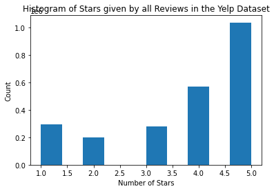

```python
plt.hist(yelp_data["review_stars"])
plt.xlabel("Number of Stars")
plt.ylabel("Count")
plt.title("Histogram of Stars given by all Reviews in the Yelp Dataset")
plt.show()
```

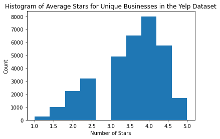

```python
plt.hist(yelp_data.drop_duplicates('business_id')['stars'])
plt.xlabel("Number of Stars")
plt.ylabel("Count")
plt.title("Histogram of Average Stars for Unique Businesses in the Yelp Dataset")
plt.show()
```

These histograms just help us understand the overall distribution of review stars, which generally does seem to be centered around 4 and 5 stars. What is interesting is although the highest number of stars is a 5 star for reviews, most businesses tend to be skewed closer to 3 and 4 stars.

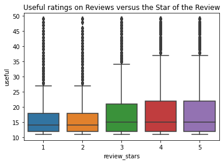

```python
sns.boxplot(y = yelp_data[ (yelp_data["useful"] > 10) & (yelp_data["useful"] < 50)]["useful"], x = yelp_data["review_stars"]).set_title("Useful ratings on Reviews versus the Star of the Review")
```

This just details another introductory analysis questioning how useful each review is at different stars. While there does seem to be a slight upper trend on the higher stars, this question of how useful a review is is insignificant.

## Analysis 1: Positivity/ Negativity Test

Here, we start the positivity negative analysis by using 11 hand picked words that could generally be used for a good/ bad food review. We would like to point out that **The choice of words does not matter** since we are only using these words to compare against themselves within other review stars.

For example: we would compare the frequency of these 11 words used between a 4 star and a 2 star rating, and test the significance.

```python
bad_list = ["disgusting", "horrible", "bad", "terrible", "gross", "hate", "awful", "garbage", "unacceptable", "shit", "negative"]
good_list = ["amazing", "love", "great", "delicious", "awesome", "excellent", "satisfying", "wonderful", "pleasing", "positive", "tasty"]
```

```python
from collections import Counter

comments = yelp_data["text"]

counter = Counter()
for comment in comments:
    counter.update(word.strip('.,?!"\'').lower() for word in comment.split())
```

We implement a counter system that also strips punctuation and capitalization that goes through all the comments in the yelp dataset, and will use this for comparing the positive negative word frequency.

```python
counter.most_common(40)
```

```
[('the', 12389130),
 ('and', 8402654),
 ('i', 6150138),
 ('a', 6117771),
 ('to', 5467752),
 ('was', 4396872),
 ('of', 3553570),
 ('it', 3173237),
 ('is', 3108958),
 ('for', 2838317),
 ('in', 2570772),
 ('this', 2068460),
 ('my', 2050531),
 ('we', 1987535),
 ('with', 1983445),
 ('but', 1926951),
 ('that', 1893564),
 ('they', 1848475),
 ('you', 1683668),
 ('on', 1622163),
 ('have', 1460785),
 ('had', 1423898),
 ('not', 1423851),
 ('food', 1407680),
 ('so', 1355500),
 ('were', 1303965),
 ('good', 1246180),
 ('place', 1240935),
 ('are', 1235206),
 ('at', 1148738),
 ('be', 1042266),
 ('as', 1026384),
 ('great', 1009212),
 ('very', 930366),
 ('there', 873731),
 ('here', 870225),
 ('like', 829315),
 ('all', 822554),
 ('service', 814961),
 ('if', 812297)]
```

We used a counter methodology to see the top 40 words in the dataset, however since most of these are rather useless words, we cannot make a judgement based off this without filtering that. For this experiment however, we decided to filter based on chosen words.

```python
star1 = yelp_data[yelp_data["review_stars"]==1]
star2 = yelp_data[yelp_data["review_stars"]==2]
star3 = yelp_data[yelp_data["review_stars"]==3]
star4 = yelp_data[yelp_data["review_stars"]==4]
star5 = yelp_data[yelp_data["review_stars"]==5]
```

```python
def counterize (comments):

    counterLoop = Counter()
    for comment in comments:
        counterLoop.update(word.strip('.,?!"\'').lower() for word in comment.split())

    return counterLoop
```

```python
counter1 = counterize(star1["text"])
counter2 = counterize(star2["text"])
counter3 = counterize(star3["text"])
counter4 = counterize(star4["text"])
counter5 = counterize(star5["text"])
```

We then subsetted the dataset by stars and then used the word counter to understand the freqency in the good and bad word list.

```python
bad1 = []
for i in bad_list:
    bad1.append(counter1[i])
bad2 = []
for i in bad_list:
    bad2.append(counter2[i])
bad3 = []
for i in bad_list:
    bad3.append(counter3[i])
bad4 = []
for i in bad_list:
    bad4.append(counter4[i])
bad5 = []
for i in bad_list:
    bad5.append(counter5[i])
```

```python
good1 = []
for i in good_list:
    good1.append(counter1[i])
good2 = []
for i in good_list:
    good2.append(counter2[i])
good3 = []
for i in good_list:
    good3.append(counter3[i])
good4 = []
for i in good_list:
    good4.append(counter4[i])
good5 = []
for i in good_list:
    good5.append(counter5[i])
```

### Results from Analysis

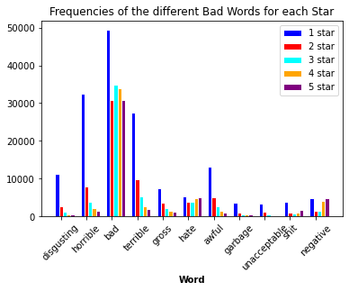

```python
# set width of bar
barWidth = 0.15

# Set position of bar on X axis
r1 = np.arange(len(bad1))
r2 = [x + barWidth for x in r1]
r3 = [x + barWidth for x in r2]
r4 = [x + barWidth for x in r3]
r5 = [x + barWidth for x in r4]

# Make the plot
plt.bar(r1, bad1, color='blue', width=barWidth, edgecolor='white', label='1 star')
plt.bar(r2, bad2, color='red', width=barWidth, edgecolor='white', label='2 star')
plt.bar(r3, bad3, color='cyan', width=barWidth, edgecolor='white', label='3 star')
plt.bar(r4, bad4, color='orange', width=barWidth, edgecolor='white', label='4 star')
plt.bar(r5, bad5, color='purple', width=barWidth, edgecolor='white', label='5 star')

# Add xticks on the middle of the group bars
plt.xlabel('Word', fontweight='bold')
plt.xticks([r + barWidth for r in range(len(bad1))], bad_list, rotation=45)
plt.title("Frequencies of the different Bad Words for each Star")

# Create legend & Show graphic
plt.legend()
plt.show()
```

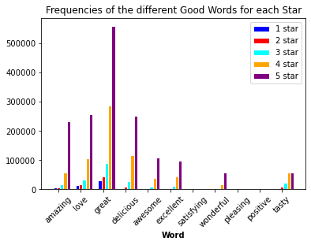

```python
import numpy as np
import matplotlib.pyplot as plt

# set width of bar
barWidth = 0.15

# Set position of bar on X axis
r1 = np.arange(len(good1))
r2 = [x + barWidth for x in r1]
r3 = [x + barWidth for x in r2]
r4 = [x + barWidth for x in r3]
r5 = [x + barWidth for x in r4]



# Make the plot
plt.bar(r1, good1, color='blue', width=barWidth, edgecolor='white', label='1 star')
plt.bar(r2, good2, color='red', width=barWidth, edgecolor='white', label='2 star')
plt.bar(r3, good3, color='cyan', width=barWidth, edgecolor='white', label='3 star')
plt.bar(r4, good4, color='orange', width=barWidth, edgecolor='white', label='4 star')
plt.bar(r5, good5, color='purple', width=barWidth, edgecolor='white', label='5 star')

# Add xticks on the middle of the group bars
plt.xlabel('Word', fontweight='bold')
plt.xticks([r + barWidth for r in range(len(good1))], good_list, rotation=45)
plt.title("Frequencies of the different Good Words for each Star")

# Create legend & Show graphic
plt.legend()
plt.show()
```

### Interpretation

From these two graphs we can generally see an upward trend on good words and a downward trend on bad words for different stars. Although this does not exactly prove our prediction we made earlier, we do see a general trend in the analysis. We asked ourselves how to better understand this trend and we determined, that we will use regression plots to further showcase this trend.

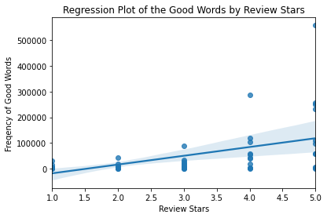

```
Regression slope is: 34178.45
Regression score is: 0.25
```

```python
goodlist = good1 + good2 + good3 + good4 + good5

starcounts = ([1]*11) + ([2]*11) + ([3]*11) + ([4]*11) + ([5] * 11)

goodframe = pd.DataFrame(data = {'good_freq':goodlist, 'stars':starcounts })

sns.regplot(x="stars", y="good_freq", data=goodframe)
plt.xlabel("Review Stars")
plt.ylabel("Freqency of Good Words")
plt.title("Regression Plot of the Good Words by Review Stars")
plt.show()

model = LinearRegression()
model.fit(goodframe[["stars"]], goodframe["good_freq"])

print(f"Regression slope is: {model.coef_[0]:.2f}")
print(f"Regression score is: {model.score(goodframe[['stars']], goodframe['good_freq']):.2f}")
```

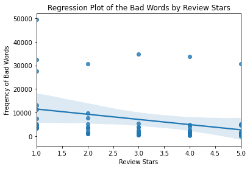

```
Regression slope is: -2200.49
Regression score is: 0.08
```

```python
badlist = bad1 + bad2 + bad3 + bad4 + bad5

starcounts = ([1]*11) + ([2]*11) + ([3]*11) + ([4]*11) + ([5] * 11)

badframe = pd.DataFrame(data = {'bad_freq':badlist, 'stars':starcounts })

sns.regplot(x="stars", y="bad_freq", data=badframe)
plt.xlabel("Review Stars")
plt.ylabel("Freqency of Bad Words")
plt.title("Regression Plot of the Bad Words by Review Stars")
plt.show()

model = LinearRegression()
model.fit(badframe[["stars"]], badframe["bad_freq"])

print(f"Regression slope is: {model.coef_[0]:.2f}")
print(f"Regression score is: {model.score(badframe[['stars']], badframe['bad_freq']):.2f}")
```

### Interpretation

When conducting a regression plot between the good and bad word frequencies against stars, we can see this trend even better with the regression line. Note that the slope values do not mean anything when comparing good versus bad words because the words cannot be compared against each other. However, the scores themselves demonstrate more power, as it helps us understand the linearity of each graph. With a score of 0.25 in the good words and 0.08 in the bad words list, we can see that there is more linearity with good words, demonstrating more difference between reviews in good words than in bad words.

### Evaluation of Significance

H0 = There is no difference of the good word frequency between the different star reviews.

HA = There is a significant difference of the good word frequency between the different star reviews.

```python
from scipy.stats import poisson, ttest_ind

print("P-value of 1 star vs 5 stars for good words:")
ttest_results = ttest_ind(good1, good5)
print(f"The p-value is: {ttest_results[1]:.3f}")

print("\nP-value of 2 star vs 4 stars for good words:")
ttest_results = ttest_ind(good2, good4)
print(f"The p-value is: {ttest_results[1]:.3f}")

print("\nP-value of 3 star vs 5 stars for good words:")
ttest_results = ttest_ind(good3, good5)
print(f"The p-value is: {ttest_results[1]:.3f}")

print("\nP-value of 1 star vs 3 stars for good words:")
ttest_results = ttest_ind(good1, good3)
print(f"The p-value is: {ttest_results[1]:.3f}")
```

```
P-value of 1 star vs 5 stars for good words:
The p-value is: 0.011

P-value of 2 star vs 4 stars for good words:
The p-value is: 0.034

P-value of 3 star vs 5 stars for good words:
The p-value is: 0.021

P-value of 1 star vs 3 stars for good words:
The p-value is: 0.114
```

```python
print("P-value of 1 star vs 5 stars for bad words:")
ttest_results = ttest_ind(bad1, bad5)
print(f"The p-value is: {ttest_results[1]:.3f}")

print("\nP-value of 2 star vs 4 stars for bad words:")
ttest_results = ttest_ind(bad2, bad4)
print(f"The p-value is: {ttest_results[1]:.3f}")

print("\nP-value of 3 star vs 5 stars for bad words:")
ttest_results = ttest_ind(bad3, bad5)
print(f"The p-value is: {ttest_results[1]:.3f}")

print("\nP-value of 1 star vs 3 stars for bad words:")
ttest_results = ttest_ind(bad1, bad3)
print(f"The p-value is: {ttest_results[1]:.3f}")
```

```
P-value of 1 star vs 5 stars for bad words:
The p-value is: 0.067

P-value of 2 star vs 4 stars for bad words:
The p-value is: 0.724

P-value of 3 star vs 5 stars for bad words:
The p-value is: 0.847

P-value of 1 star vs 3 stars for bad words:
The p-value is: 0.098
```

With an alpha value of 0.05, we can reject the null hypothesis for all good word t-tests except for 1 vs 3 stars, where we fail to reject the null hypothesis. For the bad words t-tests, we failed to reject the null hypothesis in all the tests.

#### Limitations of significance metrics

Since there is a rather low number of samples (n=11) for each of the word lists, and a generally high variance due to the sheer number of comments, the sample estimate may be different from the population true values. Unfortunately, since there is not a universal list of good and bad words used in reviews, it is difficult to obtain something close to the true population values. Therefore these significance metrics must be analyzed in consideration with those in mind.

### Final Interpretations and Conclusions

#### Good

For the good words, we can see that the comparison of 1 vs 5, 2 vs 4, and 3 vs 5 stars produces a p-value less than 0.05, therefore we can reject the null hypothesis that these stars are the same when comparing positivity levels. The one test: 1 vs 3 does not produce a significant p-value, but this does make sense as it is unlikely people would have many positive words when giving lower star values. The r-squared value also demonstrates more linearity with a value of 0.25, which gives some insight of significance as well. When evaluating the significant comparisons, it makes sense that these would have differentiating p-values since people would be more likely to have more positive words at 4 and 5 stars versus 1, 2, and 3 stars. Therefore, we can interpret this as the idea that people are more likely to say good words about a food industry at 3, 4, and 5 stars over the 1, and 2 star ratings. Therefore, people tend to give positive criticism mostly when there is a higher review.

#### Bad

Although there seems like a clear trend in the data, demonstrating the level of bad words as they decrease between stars, the p-values all are insignificant. The r-squared value, likewise shows small linearity with an r-squared value of 0.08. These values together demonstrate that there is not much difference in the amount of bad words used regardless of the star of the review. When we look at the bar graph, we can see words like bad, hate, and negative seem to have similar frequencies, however other words tend to follow a similar trend, so perhaps this is also another limitation in the analysis with the word choice used. Perhaps from a behavioral standpoint, people are more likely to utilize negativity on restaraunts no matter what their review is about. This makes sense as people tend to be critical in general, so they could use negativity in their criticisms no matter what the review rating is.

Overall, it seems that people are more prone to negativity when conveying biased opinions towards a restaraunt, regardless of the review type. People tend to be more positive only when they give a higher review amount (3, 4, and 5 stars). This goes in conjunction with the difficulty in working in the food industry and the biased opinions of customers in general. We can look at this in a behavioral standpoint and just say that even though we cannot compare the amount of good or bad in reviews in general, we can see the trends of those that have good and those reviews that have bad and understand how people use positivity and negativity. It seems that negativity is used very generally, and that people should learn to be less negative, especially when giving a positive review, so that restaraunts can still have more confidence in their abilities.

### Limitations

As said throughout this analysis, the word list is a non-random, handpicked list of words thought to be good/ bad and used in reviews. Therefore, we cannot accurately use these too directly compare good and bad word lists and we can only use these in an analysis between stars with the same good/ bad list. Since the scope of the list is small, we must also take in mind that there might be high variability when compared with the true population. Also, this analysis cannot accurately see negativity/ positivity in comments, since it only gets a word frequency. As described above with the negativity analysis, the bad words seem to follow different patterns, therefore the selection of words used in this analysis could detail how variable the negativity a review can be. We must stress that the word choice is definitely the biggest limitation in this experiment.

One thing of note, is that since this is a measure of the word frequencies and not how the words are used, there might be some comments in which people use words differently than intended of for a different purpose. Therefore, we cannot accurately evaluate the behavior of people in yelp reviews and only assume that the words were used for a general positive/ negative intent towards the restaraunt.

Also we noted that people tend to be critical in general, but generally when using bad criticism, people can be more detailed about why they dislike a product. Therefore, this would render the word frequency experiment as less useful, since when doing a bad review, if they do not use the words listed and use more words directed at the specific restaraunt ideas, then we cannot analyze it with the word frequency experiment. However, since this experiment is less about the criticism of a review and more about negativity, we focus on measuring the negativity rather the criticism of a review.

## Analysis 2: Rural vs. Urban Ratings

### Data Cleaning Process for this Analysis

The process for data cleaning was as follows:

We wanted to examine the relationship between population of an area and the average Yelp ratings of businesses corresponding to that area. To do so, we first cleaned our Yelp dataset. We had to use a different dataset containing different locations in United States and clean it, then merge it with our Yelp dataset. Using the merged dataset, we categorized each location on what category it falls under based on the population. Then, we took the businesses with the same locations and averaged their business ratings. The final dataset that we were working with had information on the locations, population of the locations, average business ratings of the locations, and indicators on what category the location is (i.e. "Large City/Suburb", "Mid-Size City/Suburb", and etc.).

Yelp Dataset Cleaning:

- We deleted all the entries that had businesses located outside the United States
- We changed the name of the locations under the "city" column into lowercase.

Locations and Population Dataset Cleaning:

- The original dataset had the location, state, and sometimes extra words such as 'city' in one string.
- We looped through the 'Location' column and created a list of the states, to which we mapped to its respective abbreviation.
- We then created a separate column, 'state', for all the abbreviated states to be added.
- We deleted the states and extra words that appeared in the entries listed under "Location" and changed the remaining string, which now is simply the location, to all lowercase letters. We also made the column names all lowercase.
- We categorized each entry based on the 'population_in_2019' as one of the following: Large City/Surburb, Mid-Size City/Suburb, Small City/Suburb, and Urban Cluster.

Merged Cleaning:

- After cleaning the data, we merged the two datasets based on location/city and state.
- We limited our focus to only information regarding the place, its population, category based on population, and ratings of businesses there by deleting unncessary columns.
- We created a new dataframe that contained unique locations and the average ratings of businesses in those locations, while retaining the information on the category.

```python
# Taking only USA locations
usa_only = ['AL', 'AK', 'AZ', 'AR', 'CA', 'CO', 'CT' , 'DE' , 'FL',
            'GA', 'HI' , 'ID' , 'IL', 'IN', 'IA', 'KS', 'KY' , 'LA',
            'ME','MD','MA' , 'MI', 'MN', 'MS', 'MO', 'MT', 'NE', 'NV',
            'NH','NJ','NM','NY','NC','ND','OH','OK','OR','PA','RI','SC',
            'SD','TN' ,'TX','UT','VT','VA', 'WA','WV','WI' ,'WY']
usa_yelp = yelp_data.drop_duplicates('business_id').loc[yelp_data['state'].isin(usa_only)]
usa_yelp.head()
```

|  | business_id | name | city | state | postal_code | latitude | longitude | stars | review_count | attributes | categories | hours | user_id | review_stars | useful | funny | cool | text | date |
| --- | --- | --- | --- | --- | --- | --- | --- | --- | --- | --- | --- | --- | --- | --- | --- | --- | --- | --- | --- |
| 0 | pQeaRpvuhoEqudo3uymHIQ | The Empanadas House | Champaign | IL | 61820 | 40.110446 | -88.233073 | 4.5 | 5 | {'RestaurantsAttire': "u'casual'", 'Restaurant... | Ethnic Food, Food Trucks, Specialty Food, Impo... | {'Monday': '11:30-14:30', 'Tuesday': '11:30-14... | eSQ3z93DlzkpXK_H6MFEMw | 5 | 0 | 0 | 0 | I love the empanadas from the Empanadas House!... | 2013-04-11 18:36:15 |
| 2 | j9bWpCRwpDVfwVT_V85qeA | Papaya Thai | Mesa | AZ | 85213 | 33.423705 | -111.772890 | 2.5 | 130 | {'Caters': 'False', 'OutdoorSeating': 'False',... | Food, Ethnic Food, Specialty Food, Restaurants... | {'Monday': '11:0-21:0', 'Tuesday': '11:0-21:0'... | kTi96LP1DxwlFTe9jqkayQ | 5 | 0 | 0 | 0 | I'm reviewing it on the basis of take-out. I ... | 2014-12-17 19:02:56 |
| 6 | W7hCuNdn2gzehta6eSHzgQ | Pete's Fish & Chips | Tempe | AZ | 85281 | 33.414507 | -111.923721 | 2.0 | 117 | {'NoiseLevel': "u'average'", 'BusinessAcceptsC... | Restaurants, Fish & Chips, Seafood | {'Monday': '10:30-22:0', 'Tuesday': '10:30-22:... | M8hsjur81r3_LhHo7w4sCQ | 1 | 0 | 0 | 0 | Didn't care for our square fish or the sauce. ... | 2014-12-17 21:27:09 |
| 8 | 8nP8ghEpT6WFcM6tfqAaGA | Sugar Bowl | Scottsdale | AZ | 85251 | 33.493775 | -111.925933 | 3.5 | 720 | {'RestaurantsAttire': "'casual'", 'Alcohol': "... | Ice Cream & Frozen Yogurt, Sandwiches, Food, A... | {'Monday': '11:0-22:0', 'Tuesday': '11:0-22:0'... | zzaq5Fn1U2Feut3dGxidNg | 5 | 0 | 0 | 0 | My favorite (sentimental) ice cream spot in al... | 2015-03-18 19:23:03 |
| 26 | OGVHlFHSXjHuioOvm1wVqg | The Jackman Bar & Restaurant | Avalon | PA | 15202 | 40.496381 | -80.065479 | 4.0 | 13 | {'BusinessParking': "{'garage': False, 'street... | Dive Bars, Restaurants, Comfort Food, Bars, Ni... | {'Monday': '11:30-2:0', 'Tuesday': '11:30-2:0'... | olYVlMxNCvWVWsc7GswArw | 4 | 2 | 0 | 1 | I would say that it's safe to disregard most o... | 2017-03-15 17:18:29 |

```python
print('Number of USA businesses is', len(usa_yelp))
```

```
Number of USA businesses is 22430
```

We found a dataset from https://www.census.gov/data/datasets/time-series/demo/popest/2010s-total-cities-and-towns.html#tables called 'Annual Estimates of the Resident Population for Incorporated Places of 50,000 or More, Ranked by July 1, 2019 Population: April 1, 2010 to July 1, 2019,' which we used to make a new csv file that only includes the location and population in 2019. This file is called 'Locations_Population.'

```python
# Reading the location and population CSV files
cleaned_locations = pd.read_csv('Locations_Population.csv', encoding = 'latin-1')
cleaned_locations.head()
```

|  | Location | Population_in_2019 |
| --- | --- | --- |
| 0 | New York city, New York | 8,336,817 |
| 1 | Los Angeles city, California | 3,979,576 |
| 2 | Chicago city, Illinois | 2,693,976 |
| 3 | Houston city, Texas | 2,320,268 |
| 4 | Phoenix city, Arizona | 1,680,992 |

Here, we added the states as a new column, with the abbreviation under "States" and full name "States_full"

This was done by creating a list of the state names then mapped with their abbreviations, which became a new column, "States"

```python
# Creating a states column
states = []
for i in cleaned_locations['Location']:
    pos = i.find(',')
    states.append(i[pos+2:])
```

```python
# Setting the states column to be the full state names
cleaned_locations['State_full'] = states

# Mapping the states to their abbreviations
map_states = cleaned_locations['State_full'].map({'Alabama' : 'AL', 'Alaska' : 'AK', "Arizona" : "AZ", "Arkansas" : "AR",
                                "California" : "CA", "Colorado" : "CO", "Connecticut" : "CT", "Delaware" : "DE",
                                "Florida" : "FL", "Georgia" : "GA", "Hawaii" : "HI", "Idaho" : "ID", "Illinois" : "IL",
                                "Indiana" : "IN", "Iowa" : "IA", "Kansas" : "KS", "Kentucky" : "KY", "Louisiana" : "LA",
                                "Maine" : "ME", "Maryland" : "MD", "Massachusetts" : "MA", "Michigan" : "MI",
                                "Minnesota" : "MN", "Mississippi" : "MS", "Missouri" : "MO","Montana" : "MT",
                                "Nebraska" : "NE", "Nevada" : "NV", "New Hampshire" : "NH", "New Jersey" : "NJ",
                                "New Mexico" : "NM", "New York" : "NY", "North Carolina" : "NC", "North Dakota" : "ND",
                                "Ohio" : "OH", "Oklahoma" : "OK", "Oregon" : "OR", "Pennsylvania" : "PA",
                                "Rhode Island" : "RI", "South Carolina" : "SC", "South Dakota" : "SD", "Tennessee" : "TN",
                                "Texas" : "TX", "Utah" : "UT", "Vermont" : "VT", "Virginia" : "VA", "Washington" : "WA",
                                "West Virginia" : "WV", "Wisconsin" : "WI","Wyoming" : "WY"})
# Setting the states column to be the abbreviated states
cleaned_locations['State'] = map_states
```

```python
# Changing the 'Location' column to only be the names of the location (without states)
cities = []
for l in cleaned_locations['Location']:
    pos = l.find(',')
    cities.append(l[:pos])
cleaned_locations['Location'] = cities

# Making all the column names lowercase
cleaned_locations.columns = cleaned_locations.columns.str.lower()

# Removing the extra word 'city' that appears very often
cleaned_locations['location'] = cleaned_locations.location.apply(lambda x: x.strip(' city'))

# Making all the new locations names lowercase
cleaned_locations['location'] = cleaned_locations.location.apply(lambda x: x.lower())
```

```python
# Removing all the commas in the population_in_2019 to have solely numbers
num_pop = []
for i in cleaned_locations['population_in_2019']:
    i = i.replace(',', '')
    num_pop.append(i)

# Setting the new array as the population_in_2019 column
cleaned_locations['population_in_2019'] = num_pop

# Converting this column's data to type int
cleaned_locations['population_in_2019'] = cleaned_locations['population_in_2019'].astype(int)
```

```python
print('The lowest population is', cleaned_locations.population_in_2019.min())
print('The highest population is', cleaned_locations.population_in_2019.max())
```

```
The lowest population is 46536
The highest population is 8336817
```

Let's try to categorize the populations.

According to the NCES Locale Classifications and Criteria, https://nces.ed.gov/programs/edge/docs/LOCALE_CLASSIFICATIONS.pdf and https://www.census.gov/programs-surveys/geography/guidance/geo-areas/urban-rural.html :

- City/Suburban (Large) = population of 250,000 or more
- City/Suburban (Midsize) = population greater than or equal to 100,000 and less than 250,000
- City/Suburban (Small) = population greater than or equal to 50,000 and less than 100,000
- Urban Clusters (UCs) = population of greater than or equal to 2,500 and less than 50,000
- Rural Areas = population less than 2,500

We can ignore the Rural Areas since the minimum size of the population in the dataset is larger than this category.

```python
# Creating New columns to categorize the populations

# population: 2,500 - 50,000
cleaned_locations['urban_clusters'] = (np.zeros(len(cleaned_locations))).astype(int)

# population: 50,000 - 100,000
cleaned_locations['small_cs'] = np.zeros(len(cleaned_locations)).astype(int)

# population: 100,000 - 250,000
cleaned_locations['middle_cs'] = (np.zeros(len(cleaned_locations))).astype(int)

# population: > 250,000
cleaned_locations['large_cs'] = (np.zeros(len(cleaned_locations))).astype(int)
```

```python
# 1 if it belongs to a certain category of population
# 0 if it does not belong in a certain category of population

for index, row in cleaned_locations.iterrows():
    if ((row['population_in_2019'] >= 2500) & (row['population_in_2019'] < 50000)):
        cleaned_locations.at[index, 'urban_clusters'] = 1
    elif ((row['population_in_2019'] >= 50000) & (row['population_in_2019'] < 100000)):
        cleaned_locations.at[index, 'small_cs'] = 1
    elif ((row['population_in_2019'] >= 100000) & (row['population_in_2019'] < 250000)):
        cleaned_locations.at[index, 'middle_cs'] = 1
    else:
        cleaned_locations.at[index, 'large_cs'] = 1
```

```python
cleaned_locations.head()
```

|  | location | population_in_2019 | state_full | state | urban_clusters | small_cs | middle_cs | large_cs |
| --- | --- | --- | --- | --- | --- | --- | --- | --- |
| 0 | new york | 8336817 | New York | NY | 0 | 0 | 0 | 1 |
| 1 | los angeles | 3979576 | California | CA | 0 | 0 | 0 | 1 |
| 2 | chicago | 2693976 | Illinois | IL | 0 | 0 | 0 | 1 |
| 3 | houston | 2320268 | Texas | TX | 0 | 0 | 0 | 1 |
| 4 | phoenix | 1680992 | Arizona | AZ | 0 | 0 | 0 | 1 |

```python
# making cities lowercase in the USA Yelp data

pd.options.mode.chained_assignment = None
lower_city = []
for i in usa_yelp['city']:
    i = i.lower()
    lower_city.append(i)
usa_yelp['city'] = lower_city
```

```python
# Merging the two datasets
usa_yelp_population = usa_yelp.merge(cleaned_locations, how = 'inner', left_on = ['state', 'city'], right_on = ['state', 'location'])

# Preview of the merged dataset
usa_yelp_population.head()
```

|  | business_id | name | city | state | postal_code | latitude | longitude | stars | review_count | attributes | ... | cool | text | date | location | population_in_2019 | state_full | urban_clusters | small_cs | middle_cs | large_cs |
| --- | --- | --- | --- | --- | --- | --- | --- | --- | --- | --- | --- | --- | --- | --- | --- | --- | --- | --- | --- | --- | --- |
| 0 | pQeaRpvuhoEqudo3uymHIQ | The Empanadas House | champaign | IL | 61820 | 40.110446 | -88.233073 | 4.5 | 5 | {'RestaurantsAttire': "u'casual'", 'Restaurant... | ... | 0 | I love the empanadas from the Empanadas House!... | 2013-04-11 18:36:15 | champaign | 88909 | Illinois | 0 | 1 | 0 | 0 |
| 1 | -fiUXzkxRfbHY9TKWwuptw | DESTIHL Restaurant & Brew Works | champaign | IL | 61820 | 40.118337 | -88.243777 | 4.0 | 712 | {'GoodForKids': 'True', 'OutdoorSeating': 'Tru... | ... | 0 | I really like the atmosphere of this restauran... | 2012-04-28 21:37:12 | champaign | 88909 | Illinois | 0 | 1 | 0 | 0 |
| 2 | TEXUVhF-G_v2Sxwqti8HQA | Old Chicago | champaign | IL | 61820 | 40.139982 | -88.244108 | 3.0 | 96 | {'Alcohol': "u'full_bar'", 'RestaurantsReserva... | ... | 0 | I gave this place a second chance and the serv... | 2015-08-19 11:45:46 | champaign | 88909 | Illinois | 0 | 1 | 0 | 0 |
| 3 | sYf2auhosrx8trbyP9nGyw | DP Dough | champaign | IL | 61820 | 40.109763 | -88.240838 | 3.0 | 63 | {'RestaurantsAttire': "'casual'", 'Restaurants... | ... | 0 | I always have a good experience when i order f... | 2017-07-28 20:13:56 | champaign | 88909 | Illinois | 0 | 1 | 0 | 0 |
| 4 | 5bTjUBhGbild5tuzfAmIJg | Denny's | champaign | IL | 61822 | 40.143262 | -88.254794 | 2.0 | 66 | {'RestaurantsAttire': "u'casual'", 'OutdoorSea... | ... | 0 | Are you kidding me? This was THE worst service... | 2017-04-30 07:32:41 | champaign | 88909 | Illinois | 0 | 1 | 0 | 0 |

5 rows × 26 columns

```python
# deleting unncessary columns for the analysis
usa_clean = usa_yelp_population.drop(['business_id','name','postal_code','latitude',
                          'longitude', 'attributes', 'categories', 'hours',
                          'user_id', 'review_stars', 'useful', 'funny', 'cool', 'text', 'date'], axis = 1)
```

```python
usa_clean.head()
```

|  | city | state | stars | review_count | location | population_in_2019 | state_full | urban_clusters | small_cs | middle_cs | large_cs |
| --- | --- | --- | --- | --- | --- | --- | --- | --- | --- | --- | --- |
| 0 | champaign | IL | 4.5 | 5 | champaign | 88909 | Illinois | 0 | 1 | 0 | 0 |
| 1 | champaign | IL | 4.0 | 712 | champaign | 88909 | Illinois | 0 | 1 | 0 | 0 |
| 2 | champaign | IL | 3.0 | 96 | champaign | 88909 | Illinois | 0 | 1 | 0 | 0 |
| 3 | champaign | IL | 3.0 | 63 | champaign | 88909 | Illinois | 0 | 1 | 0 | 0 |
| 4 | champaign | IL | 2.0 | 66 | champaign | 88909 | Illinois | 0 | 1 | 0 | 0 |

```python
# New dataframe consisting of only unique locations, average business ratings, and category information

# unique locations column
unique_locations = []
for i in usa_clean.groupby('city').city.unique():
    unique_locations.append(i[0])

# average stars column
average_stars = []
for i in usa_clean.groupby('city').stars.mean():
    average_stars.append(i)

# population column
population_col = []
for i in usa_clean.groupby('city').population_in_2019.mean():
    population_col.append(i)

# Is the location an urban cluster?
uc = []
for i in usa_clean.groupby('city').urban_clusters.mean():
    uc.append(i)

# Is the location a small city/suburban?
s_cs = []
for i in usa_clean.groupby('city').small_cs.mean():
    s_cs.append(i)

# Is the location a mid-size city/suburban?
m_cs = []
for i in usa_clean.groupby('city').middle_cs.mean():
    m_cs.append(i)

# Is the location a large city/suburban?
l_cs = []
for i in usa_clean.groupby('city').large_cs.mean():
    l_cs.append(i)

info = {'location': unique_locations,
       'avg_stars': average_stars,
       'population': population_col,
       'urban_clusters': uc,
       'small_city_sub': s_cs,
       'mid_city_sub': m_cs,
       'large_city_sub': l_cs,
       }
# New dataframe
unique_usa = pd.DataFrame(info)
```

```python
# categorizing each population type where:
# 1 = Urban Cluster
# 2 = Small City/Suburb
# 3 = Mid-Size City/Suburb
# 4 = Large City/Suburb

# Creating a new column to put these categories
unique_usa['category'] = np.zeros(len(unique_usa))

# Adding the category data
for index, row in unique_usa.iterrows():
    if row['urban_clusters'] == 1:
        unique_usa.at[index, 'category'] = 1
    elif row['small_city_sub'] == 1:
        unique_usa.at[index, 'category'] = 2
    elif row['mid_city_sub'] == 1:
        unique_usa.at[index, 'category'] = 3
    elif row['large_city_sub'] == 1:
        unique_usa.at[index, 'category'] = 4

# Converting to type int
unique_usa['category'] = unique_usa.category.astype(int)
```

```python
# Preview of the new dataframe
unique_usa.head()
```

|  | location | avg_stars | population | urban_clusters | small_city_sub | mid_city_sub | large_city_sub | category |
| --- | --- | --- | --- | --- | --- | --- | --- | --- |
| 0 | akron | 3.448113 | 197597 | 0 | 0 | 1 | 0 | 3 |
| 1 | avondale | 3.271318 | 87931 | 0 | 1 | 0 | 0 | 2 |
| 2 | buckeye | 3.607143 | 79620 | 0 | 1 | 0 | 0 | 2 |
| 3 | champaign | 3.375576 | 88909 | 0 | 1 | 0 | 0 | 2 |
| 4 | chandler | 3.491950 | 261165 | 0 | 0 | 0 | 1 | 4 |

### Analysis

We will examine how well the populations of various locations explain the average star ratings of businesses in those areas through a linear model.

```python
from sklearn.linear_model import LinearRegression
import seaborn as sns
```

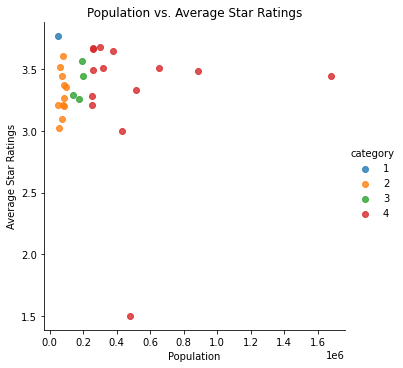

```python
# Scatterplot of population and the average business ratings
sns.lmplot(x = 'population', y= 'avg_stars', data = unique_usa, hue = 'category', fit_reg = False, legend = True)
plt.xlabel('Population')
plt.ylabel('Average Star Ratings')
plt.title('Population vs. Average Star Ratings')
plt.show()
```

#### Legend

The data points are colored according to what type of area they belong to.

- 1 = Urban Cluster (Blue data points)
- 2 = Small City/Suburb (orange data points)
- 3 = Mid-Size City/Suburb (green data points)
- 4 = Large City/Suburb (red data points)

```python
# Linear Regression with input variable being population and output variable being average business ratings
pop_reg = LinearRegression().fit(unique_usa[['population']], unique_usa['avg_stars'])
print('The slope is {:.3f}'.format(pop_reg.coef_[0]))
print('The r-squared value is {:.3f}'.format(pop_reg.score(usa_yelp_population[['population_in_2019']], usa_yelp_population['stars'])))
```

```
The slope is -0.000
The r-squared value is -0.035
```

### Interpretation

This is further evident by observing the r-squared value. The r-squared value depicts how well our model fits the data. If it is close to 1, it means that our linear model is a good fit for the data. If the r-sqaured value is close to 0, it means that our model is a poor fit for the data.

### Limitations

Another thing to remember when looking at these results is the sample size. Due to the method of cleaning the data where we tried to match location names and states with population data from a different dataset, we were only able to acquire 30 unique locations. There were multiple instances where the location names and states of both datasets were the same but the way the location was written in one dataset was different, and therefore, could not be matched. We attempted to match the locations and cities manually but we were unable to accomplish that due to the size of the dataset (approximately 2 million data points). Given that the sample size is 30, it is not large enough to be certain of our results.

As noted above, our data led us to a conclusion that there was no relationship between the population of a location and the average star ratings of that particular location. However, will this be true if we were to focus in on less populated areas and highly populated areas?

Let's examine this through seeing how different are the average star ratings of businesses in highly populated locations versus the average star ratings of businesses in less populated locations.

```python
print('There is {} urban cluster'.format(unique_usa.urban_clusters.sum()))
print('There are {} small cities/suburbs'.format(unique_usa.small_city_sub.sum()))
print('There are {} mid-size cities/suburbs'.format(unique_usa.mid_city_sub.sum()))
print('There are {} large cities/suburbs'.format(unique_usa.large_city_sub.sum()))
```

```
There is 1 urban cluster
There are 11 small cities/suburbs
There are 4 mid-size cities/suburbs
There are 14 large cities/suburbs
```

Given that most of the data is in the "small cities/suburbs" and "large cities/suburbs", we will focus on those categories as our less populated locations and highly populated locations respectively.

```python
# finding the average rating of small cities/suburbs
small_sum = 0
small_count = 0
for index, row in unique_usa.iterrows():
    if row['small_city_sub'] == 1:
        small_sum = small_sum + row['avg_stars']
        small_count += 1
print('The average star rating in small cities/suburbs is {:.5f}'.format(small_sum/small_count))

# finding the average rating of large cities/suburbs
large_sum = 0
large_count = 0
for index, row in unique_usa.iterrows():
    if row['large_city_sub'] == 1:
        large_sum = large_sum + row['avg_stars']
        large_count += 1
print('The average star rating in large cities/suburbs is {:.5f}'.format(large_sum/large_count))

# Difference between the two averages
diff = (large_sum/large_count)-(small_sum/small_count)
print('The difference between the average ratings of small and large cities/suburbs is {:.5f}'.format(diff))
```

```
The average star rating in small cities/suburbs is 3.30119
The average star rating in large cities/suburbs is 3.31798
The difference between the average ratings of small and large cities/suburbs is 0.01679
```

It appears that on average, large cities/suburbs have a slightly higher average star rating than small cities/suburbs, though the difference is miniscule. In fact, it is extremely close to 0, meaning almost no difference.

### Evaluation of Significance

Let's evaluate how significant this result is using a t-test of independence and permutation test.

#### T-Test of Independence

```python
from scipy.stats import ttest_ind
from matplotlib import pyplot
```

```python
# array of small cities/suburbs locations' average star ratings
small_stars = []
for index, row in unique_usa.iterrows():
    if row['small_city_sub'] == 1:
        small_stars.append(row['avg_stars'])

# array of large cities/suburbs locations' average star ratings
large_stars = []
for index, row in unique_usa.iterrows():
    if row['large_city_sub'] == 1:
        large_stars.append(row['avg_stars'])
```

### Limitation

Given how our data is small in size (n = 11 and n = 14), we cannot approximate the population variance from our sample variance. There was no information regarding whether the true variance of small cities/suburbs and large cities/suburbs are the same or not. For simplicity, we will assume the true variances of both samples are the same.

H0: The difference in the means of the two groups is 0.

HA: The difference in the means of the two groups is not 0.

```python
# conducting a t-test

t_result = ttest_ind(small_stars, large_stars)
print('The test statistics is aproximately {:.3f}'.format(t_result[0]))
print('The p-value is aproximately {:.3f}'.format(t_result[1]))
```

```
The test statistics is aproximately -0.095
The p-value is aproximately 0.925
```

### Interpretation

If we have a large p-value that exceeds a certain signifiance level or is extremely close to 1, we fail to reject the null hypothesis. If we have a low p-value that is below a certain signifiance level or is extremely close to 0, we reject the null hypothesis and accept the alternate hypothesis as the more likely outcome.

From our data, there's a large p-value. In fact, it is very close to 1. A p-value close to 0 means that the null hypothesis of no difference between the means of both samples (small cities/suburbs' and large cities/suburbs' average star ratings) is false (meaning there is a difference). A p-value close to 1, like in our case, means that the null hypothesis is more likely to be true and since our p-value is extremely close to 1, this means there's almost no difference in the means of the two samples.

#### Permutation Test

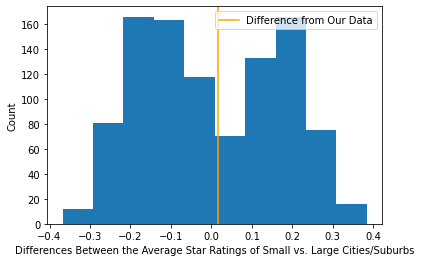

```python
# randomly permuting our samples to generate a series of differences
differences = np.zeros(1000)
for n in range(1000):
    combined = np.zeros(len(small_stars) + len(large_stars))
    for i in range(len(small_stars)):
        combined[i] = small_stars[i]
    for i in range(len(large_stars)):
        combined[i+len(small_stars)] = large_stars[i]
    random_combined = np.random.permutation(combined)
    small_ = random_combined[:11] # 11 observations for the small cities/suburbs to be consistent with the original data
    large_ = random_combined[11:] # 14 observations for the large cities/suburbs to be consistent with the original data
    # difference between the two samples' means
    d = large_.mean() - small_.mean()
    differences[n] = d

# plotting the various random differences
pyplot.hist(differences)
pyplot.xlabel('Differences Between the Average Star Ratings of Small vs. Large Cities/Suburbs')
pyplot.ylabel('Count')
pyplot.axvline(x=diff, color = 'orange', label = 'Difference from Our Data')
pyplot.legend(loc = 'best')
pyplot.show()
```

### Interpretation

As we can see, the difference between the small cities/suburbs' average star rating and the large cities/suburbs'average star rating from our data falls right in the middle of the 1000 random differences we have generated. Since this value is right in the center of the range of the possible differences from randomly permuting the data, we can say that the two categories' average star ratings are not different. If the difference from our actual data had fallen outside the range of the possible differences, it would mean that the two categories' average star ratings are different.

## Raw Data Sets

- Yelp Dataset: https://www.kaggle.com/yelp-dataset/yelp-dataset/data
- Location and Population Dataset: https://www.census.gov/data/datasets/time-series/demo/popest/2010s-total-cities-and-towns.html#tables
  - We examined the "Annual Estimates of the Resident Population for Incorporated Places of 50,000 or More, Ranked by July 1, 2019 Population: April 1, 2010 to July 1, 2019" data

## Information

- The Breakdown of each Population Category:
  - https://nces.ed.gov/programs/edge/docs/LOCALE_CLASSIFICATIONS.pdf
  - https://www.census.gov/programs-surveys/geography/guidance/geo-areas/urban-rural.html
- The Permutation Test method:
  - https://www.sciencedirect.com/topics/mathematics/permutation-test

## Acknowledgement

- We obtained assistance with our code from these sources:
  - Json Parsing and Merging Tutorial on the Yelp dataset:
    - https://www.dataquest.io/blog/python-json-tutorial/
  - Merging two datasets:
    - https://stackoverflow.com/questions/53549492/joining-two-pandas-dataframes-based-on-multiple-conditions?fbclid=IwAR1t2GxFtobhEn_Uxpv-Iru5-F13peLsgaGEATbT2frnS3v0IjuQGv27Q50
  - Updating a dataframe:
    - https://stackoverflow.com/questions/23330654/update-a-dataframe-in-pandas-while-iterating-row-by-row